# 08 - publication quality plots using ggplot

Jenny Bigman

5/12/2022

Let’s learn how to modify a plot to make it ready for publication in a journal. The `theme()` function has endless arguments you can call to customize your plot. There are built-in themes (we have used one, `theme_classic()`, but you can also modify (probably) any component. Look here: https://ggplot2.tidyverse.org/reference/theme.html. Keep in mind, not all modifcations will be in the theme function.

Let’s work with the plot we saved from the last exercise and start with a few simple modifications. We’ve already learned how to rename our axes, but let’s work on formatting them.

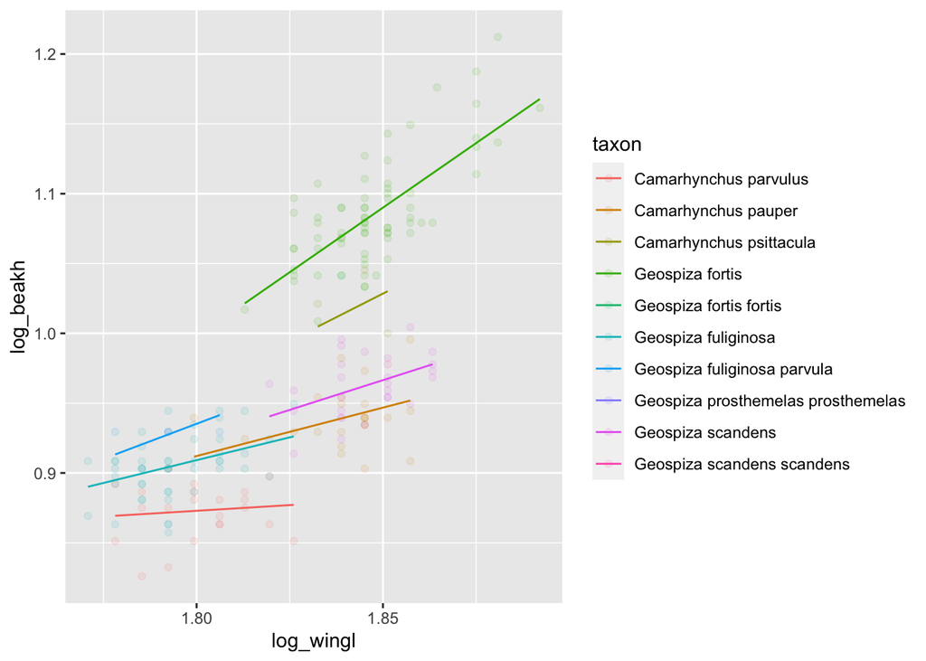

```r
mem_plot1
```

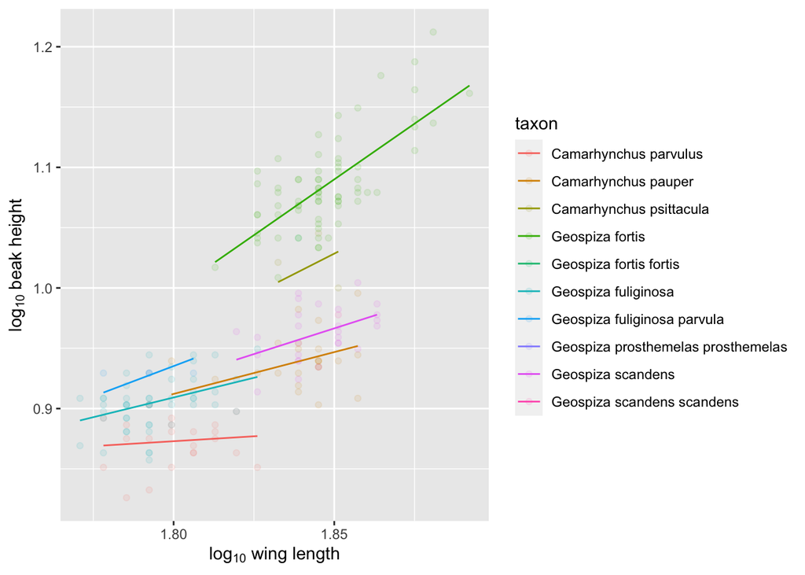

```r
# we want log10 to show up as log(subscript 10)

# many ways to do this, here's one

x_lab <- expression(paste(log[10], " wing length"))
# why the extra space before wing
y_lab <- expression(paste(log[10], " beak height"))

# if you wanted to do a superscript instead
#super <- expression(paste(x^{10}, " x wing length"))

    mem_plot1 +
        labs(x = x_lab, y = y_lab)
```

Let’s modify components of the theme. To do so, you will specify an argument (e.g., `axis.title()`) and then specify an element (e.g., `element_line()`, `element_rect()`, `element_text()`, or `element_blank()`). Which of these elements you use depends on the argument. For example, if you want to modify the size of text, this is a text element (use `element_text()`). Then, you’d fill in a few more arguments (e.g., `size = 16`). If you don’t want a given component (axis labels, panel.grid, etc) use `element_blank()` (with nothing in the parentheses). You can also specify which axis you want to change if you do not want to change both (e.g., `axis.line.x = element_line()` will change the x axis and `axis.line = element_line()` will change both). Let’s play around with this.

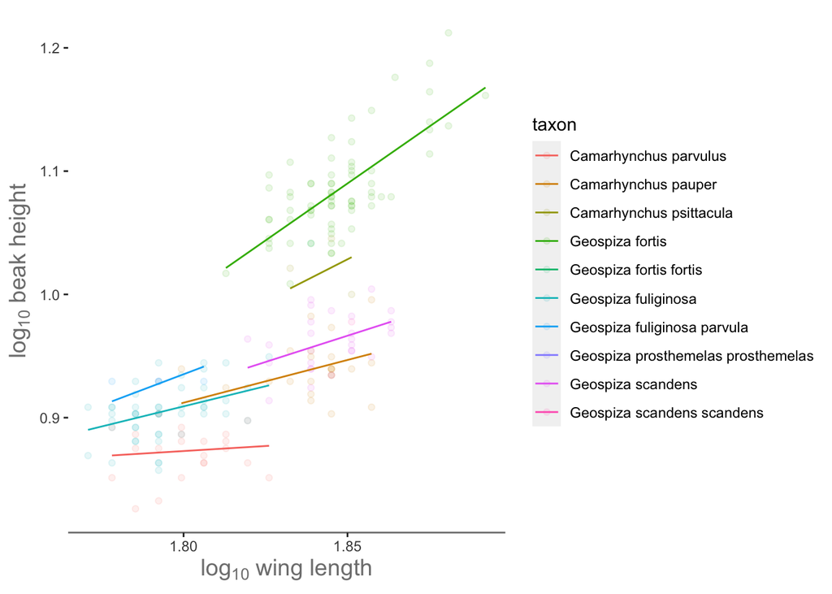

```r
    mem_plot1 +
        labs(x = x_lab, y = y_lab) +
        theme(
            axis.title = element_text(size = 14, color = "grey50"),
            panel.grid.major = element_blank(),
            panel.grid.minor = element_blank(),
            panel.background = element_rect(fill = "transparent"),
        plot.background = element_rect(fill = "transparent", color = NA),
            axis.line.x = element_line(color = "grey50"))
```

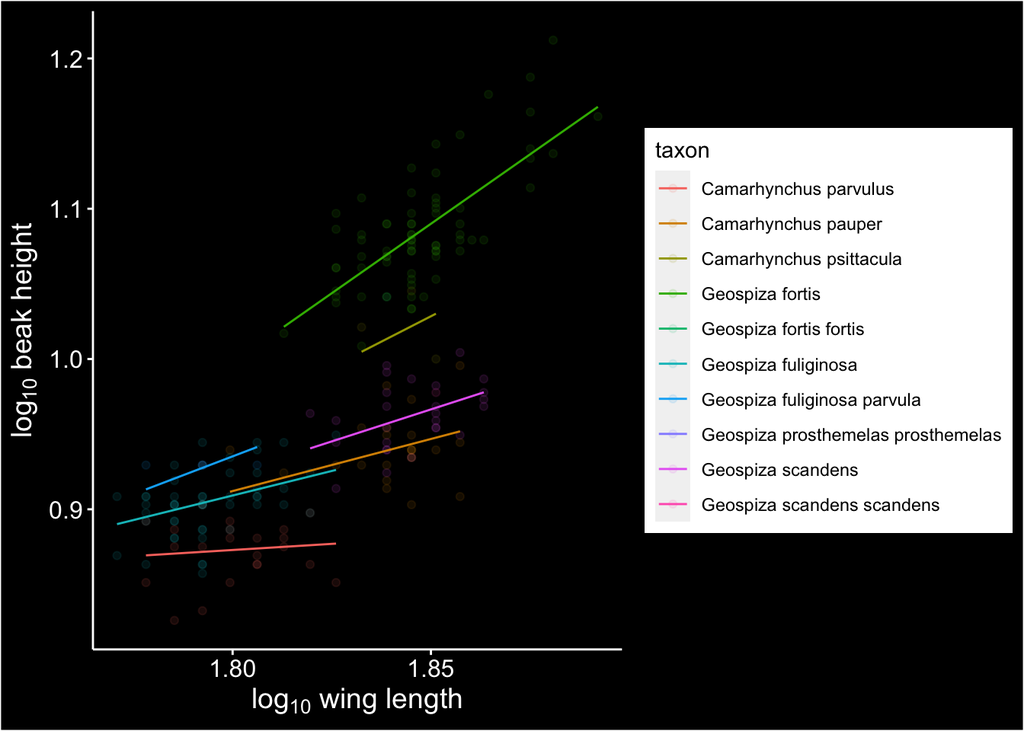

```r
# both axes, black background, white text
    mem_plot1 +
        labs(x = x_lab, y = y_lab) +
        theme(
            axis.title = element_text(size = 14, color = "white"),
            axis.ticks = element_line(color = "white"),
            axis.text = element_text(size = 12, color = "white"),
            axis.line = element_line(color = "white"),
            panel.grid = element_blank(),
            panel.background = element_rect(fill = "black"),
        plot.background = element_rect(fill = "black"))
```

Let’s deal with the legend. Even though the legend is in the theme section, it works a little differently. To remove it, you specify `legend.position = "none"`.

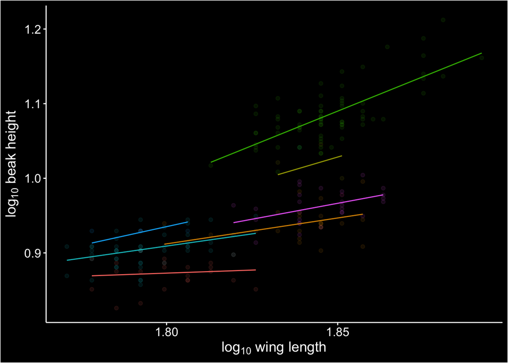

```r
    mem_plot1 +
        labs(x = x_lab, y = y_lab) +
        theme(
            axis.title = element_text(size = 14, color = "white"),
            axis.ticks = element_line(color = "white"),
            axis.text = element_text(size = 12, color = "white"),
            axis.line = element_line(color = "white"),
            panel.grid = element_blank(),
            panel.background = element_rect(fill = "black"),
        plot.background = element_rect(fill = "black"),
            legend.position = "none")
```

Now we can add some text.

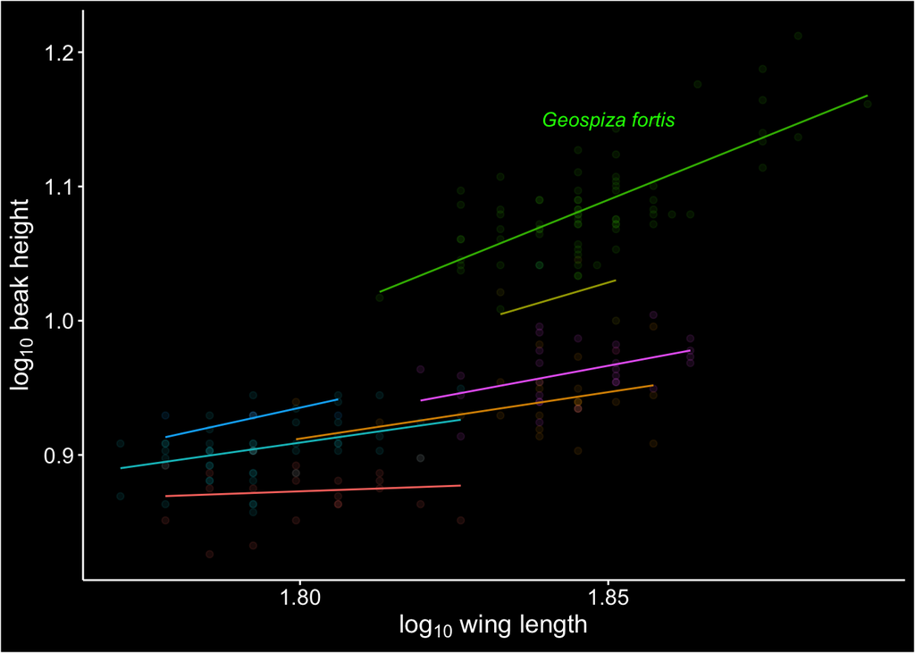

```r
black_mem_plot <- mem_plot1 +
        labs(x = x_lab, y = y_lab) +
        theme(
            axis.title = element_text(size = 14, color = "white"),
            axis.ticks = element_line(color = "white"),
            axis.text = element_text(size = 12, color = "white"),
            axis.line = element_line(color = "white"),
            panel.grid = element_blank(),
            panel.background = element_rect(fill = "black"),
        plot.background = element_rect(fill = "black"),
            legend.position = "none")

black_mem_plot +
    annotate(geom = "text", x = 1.85, y = 1.15,
                     label = "Geospiza fortis", color = "green",
                     fontface = "italic")
```

Let’s change the names of the species though because that’s a lot of text. We have to go outside of the `theme()` function.

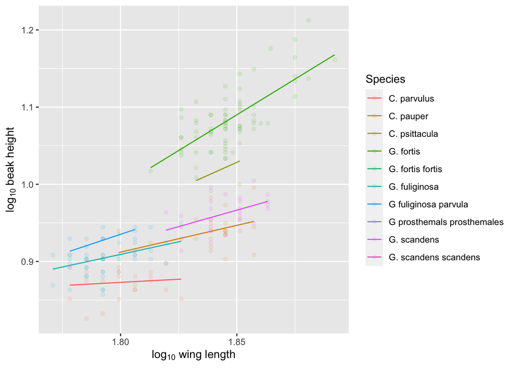

```r
mem_plot1 +
        labs(x = x_lab, y = y_lab) +
        scale_color_discrete(name="Species",
    labels = c("C. parvulus",
                         "C. pauper",
                         "C. psittacula",
                         "G. fortis",
                         "G. fortis fortis",
                         "G. fuliginosa",
                         "G fuliginosa parvula",
                         "G prosthemals prosthemales",
                         "G. scandens",
                         "G. scandens scandens"))
```

This brings us to `scale_*_` arguments. They can be very useful but also frustrating. I often use them to change the axes. The main uses of these functions are for changing the axis scale (name, limits, breaks, labels) and specifying specific colors. We already used one such function above (`scale_color_discrete()`).